# Palmer Penguin Analyses

2024-12-09

### Load the packages

```r
library(palmerpenguins)
library(ggplot2)
library(janitor)
library(dplyr)
library(here)
library(svglite)
library(stats)
library(ggsignif)
library(broom)
library(knitr)
library(kableExtra)
library(renv)
library(ggpubr)
library(car)
library(rstatix)
library(caret)
```

### Call the required functions

```r
source(here("Functions/Cleaning.R"))
source(here("Functions/AssumptionCheck.R"))
source(here("Functions/SavingFigure.R"))
source(here("Functions/Summary.R"))
source(here("Functions/Table.R"))
```

# **Section 1:** Data Visualization for Science Communication

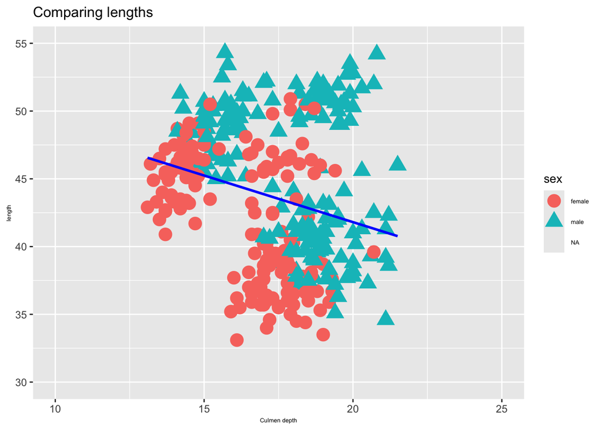

### b) Write about how your design choices mislead the reader about the underlying data (200-300 words).

The presented figure employs multiple design features that mislead the viewer and misrepresent the underlying data, reflecting common issues in scientific reporting and reproducibility. A nature survey found that 70% of researchers have tried and failed to reproduce another scientist’s work, and more than half have failed to reproduce their own (Baker 2016). The lack of reproducibility is driven by factors such as the pressure to publish, which prioritises novel findings over rigour, and selective reporting, which biases the literature toward positive results (Baker 2016).

The figure above is a good example of misleading data representation, showing a negative correlation between culmen length and depth. However, closer analysis (e.g., colouring dots by species) would reveal a positive correlation within each species. This is known as Simpson’s paradox. This data was also filtered to exclude extreme values, a practice known as cherry-picking, which can obscure the true relationship. Both cherry-picking and Simpson’s paradox are common issues in closed research processes. This figure has multiple aesthetic problems which interfere with interpretation. The text is small and ambiguous, lacking units and specificity in the measurements. The data points are large and overlapping, making it hard to understand their true distribution. Finally, the scale does not start at zero, exaggerating the negative slope, and the data points are clumped in the middle of the graph. Overall, this makes it hard to interpret the graph, and what they can gather is misleading.

The push for open access, open data, open source, and other open scholarship practices should prevent the publication of ambiguous, misleading graphs like the one above. The potential benefits of open science, such as increased media attention and collaboration opportunities, are driving its growing popularity. However, insufficient public evidence of open publishing’s effectiveness currently limits full compliance among scientists (McKiernan et al. 2016).

# **Section 2:** Data Pipeline

# Introduction

> Gentoo, Adelie, and Chinstrap are three species of penguin that are found in the Palmer Archipelago near Antarctica. This analysis seeks to determine whether these species occupy different feeding niches by comparing their bill morphology, specifically the culmen depth. Morphological plasticity in bill size has been shown to relate closely to diet and thus, niche differentiation (Laranjeiro et al. 2022). Specifically, culmen depth plays a crucial role in determining the strength and functionality of a penguin’s bill, directly influencing the types of prey the species can access. A deeper bill typically allows for the capture and handling of larger, more robust prey. As a result, if penguins have similar culmen depths, it can be inferred that they share similar feeding niches. This study aims to compare the culmen depths among the three penguin species to gain insights into their specific feeding niches.

**H0:** There is no significant difference in the mean culmen depth among the penguin species.

**H1:** At least one Penguin species mean is significantly different from the others.

### Viewing the raw data

```r
kable(head(penguins_raw), caption = "Preview of Penguin Dataset")
```

Preview of Penguin Dataset

| studyName | Sample Number | Species | Region | Island | Stage | Individual ID | Clutch Completion | Date Egg | Culmen Length (mm) | Culmen Depth (mm) | Flipper Length (mm) | Body Mass (g) | Sex | Delta 15 N (o/oo) | Delta 13 C (o/oo) | Comments |
| --- | --- | --- | --- | --- | --- | --- | --- | --- | --- | --- | --- | --- | --- | --- | --- | --- |
| PAL0708 | 1 | Adelie Penguin (Pygoscelis adeliae) | Anvers | Torgersen | Adult, 1 Egg Stage | N1A1 | Yes | 2007-11-11 | 39.1 | 18.7 | 181 | 3750 | MALE | NA | NA | Not enough blood for isotopes. |
| PAL0708 | 2 | Adelie Penguin (Pygoscelis adeliae) | Anvers | Torgersen | Adult, 1 Egg Stage | N1A2 | Yes | 2007-11-11 | 39.5 | 17.4 | 186 | 3800 | FEMALE | 8.94956 | -24.69454 | NA |
| PAL0708 | 3 | Adelie Penguin (Pygoscelis adeliae) | Anvers | Torgersen | Adult, 1 Egg Stage | N2A1 | Yes | 2007-11-16 | 40.3 | 18.0 | 195 | 3250 | FEMALE | 8.36821 | -25.33302 | NA |
| PAL0708 | 4 | Adelie Penguin (Pygoscelis adeliae) | Anvers | Torgersen | Adult, 1 Egg Stage | N2A2 | Yes | 2007-11-16 | NA | NA | NA | NA | NA | NA | NA | Adult not sampled. |
| PAL0708 | 5 | Adelie Penguin (Pygoscelis adeliae) | Anvers | Torgersen | Adult, 1 Egg Stage | N3A1 | Yes | 2007-11-16 | 36.7 | 19.3 | 193 | 3450 | FEMALE | 8.76651 | -25.32426 | NA |
| PAL0708 | 6 | Adelie Penguin (Pygoscelis adeliae) | Anvers | Torgersen | Adult, 1 Egg Stage | N3A2 | Yes | 2007-11-16 | 39.3 | 20.6 | 190 | 3650 | MALE | 8.66496 | -25.29805 | NA |

### Cleaning and filtering the data

```r
#Save a raw copy of the data before cleaning it.
write.csv(penguins_raw, "data/penguins_raw.csv")

#Clean the data
penguins_clean <- Cleaning(penguins_raw) #See annotation within the cleaning function

#Save the cleaned data set
write.csv(penguins_clean, "data/penguins_clean.csv")

#Select the collumn that will be analysed (culmen_depth_mm) and remove rows with NA. This ensures NA are only removed from the collumn being used.
penguins_clean_subset <- penguins_clean %>% select(culmen_depth_mm, species) %>% remove_NA() #Remove_NA is from within the cleaning package.
```

### Visualizing the data

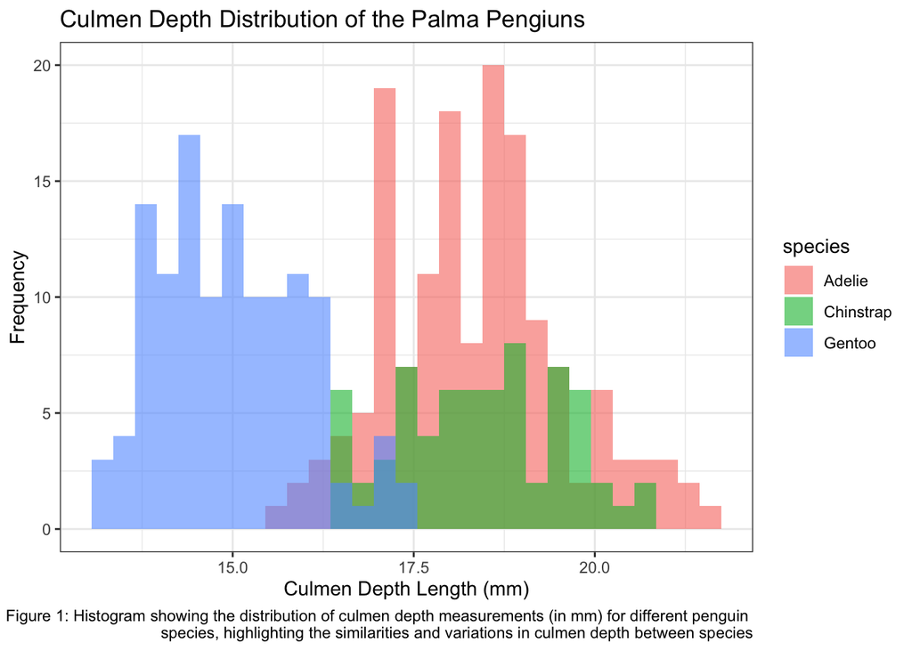

```r
# Plot a histogram of all the raw data
Flipper.Histogram <- ggplot(penguins_clean_subset, aes(x = culmen_depth_mm, fill = species)) +  # Load ggplot2 and prepare the plot
  geom_histogram(alpha = 0.6, position = "identity", binwidth = 0.3) +  # Add a histogram layer with transparency and overlapping histogram bars
  labs(
    title = "Culmen Depth Distribution of the Palma Pengiuns",
    x = "Culmen Depth Length (mm)",
    y = "Frequency",
    caption = "Figure 1: Histogram showing the distribution of culmen depth measurements (in mm) for different penguin \n species, highlighting the similarities and variations in culmen depth between species") + # Add labels for the title and axes
  theme(
    plot.caption = element_text(hjust = 0, size = 9) # Align the caption to the left and size it
  ) + theme_bw() #Set the theme

# Display the plot
print(Flipper.Histogram)
```

```r
#Saving the figure: Apply the save function
save_flipper_plot_svg(Flipper.Histogram,
                      here("Figures", "Flipper.Histogram.svg"), size = 25, scaling = 1.25)
```

### Summary statistics

```r
#Run the summary function to get the mean and SD for culmen depth
summarize_data(penguins_clean_subset, "species", "culmen_depth_mm", "Table 1: Summary Statistics of Beak Depth (mm) by Species") #Function details in function file
```

Table 1: Summary Statistics of Beak Depth (mm) by Species

| species | Mean | SD |
| --- | --- | --- |
| Adelie | 18.346 | 1.217 |
| Chinstrap | 18.421 | 1.135 |
| Gentoo | 14.982 | 0.981 |

# Methods - statistical analyses

### 1) Linear model 1

```r
# Generate the linear model
Culmen_model <- lm(culmen_depth_mm ~ species, data = penguins_clean_subset)
```

### Checking assumptions: graphical assessment

The residual plot shows there is no violation of homoscedasticity in the residuals assumptions while the QQ plot shows minor normality violations. I will run a statistical test to check whether this violation is significant.

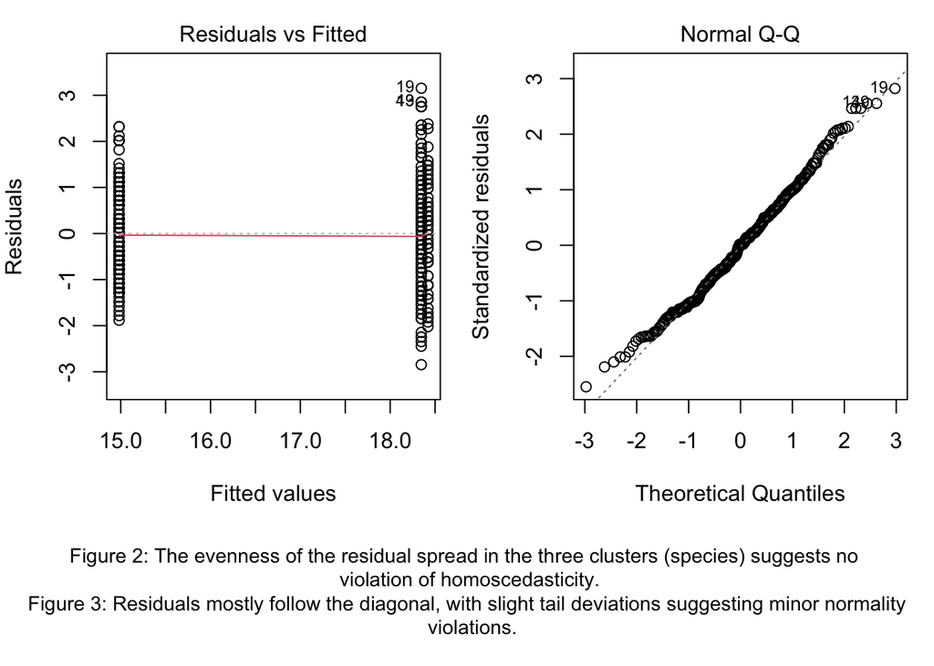

```r
#Apply the Assumption checking function
Assumption_check(Culmen_model, "Figure 2: The evenness of the residual spread in the three clusters (species) suggests no \n violation of homoscedasticity.\n Figure 3: Residuals mostly follow the diagonal, with slight tail deviations suggesting minor normality \n  violations.") #Function requires the model and the caption to be specified. #Function details in function file
```

### Checking assumptions: statistical assessment

The homoscedasticity of the data was confirmed by The Levene’s test (P > 0.05). However, the Shapiro-Wilk test identified a statistically significant violation of normality (P < 0.05). Therefore, I will apply a data transformation.

```r
#Perform statistical tests and create a table
results_table <- list(
  Shapiro_Wilk = shapiro.test(residuals(Culmen_model)), # Shapiro-Wilk Test for normality
  Levene = leveneTest(culmen_depth_mm ~ factor(species), data = penguins_clean_subset) # Levene's test for homogeneity of variance
) %>%
  {
    data.frame( # Create a data frame with the results
      Test = c("Shapiro-Wilk", "Levene's Test"),
      Statistic = c(.$Shapiro_Wilk$statistic, .$Levene$`F value`[1]), # Extract test statistics
      P_Value = c(.$Shapiro_Wilk$p.value, .$Levene$`Pr(>F)`[1]) # Extract P-values
    )
  } %>%
  mutate(
    Statistic = round(Statistic, 3), # Round test statistics to 3 decimal places
    P_Value = round(P_Value, 3)      # Round P-values to 3 decimal places
  )

#Apply function to display the results table
create_styled_table(results_table, c("Test", "Test Statistic", "P-Value"), "Table 3: Test Results for Shapiro-Wilk and Levene's Test") #Function details in function file
```

Table 3: Test Results for Shapiro-Wilk and Levene’s Test

|  | Test | Test Statistic | P-Value |
| --- | --- | --- | --- |
| W | Shapiro-Wilk | 0.992 | 0.047 |
|  | Levene’s Test | 2.037 | 0.132 |

### 2) Linear model 2

I performed a Box Cox transformation and created a second linear model.

```r
# Set up the Box Cox transformation
bc_trans <- BoxCoxTrans(penguins_clean_subset$culmen_depth_mm)

# Apply the Box-Cox transformation to the Depth data and create a new column with the transformed data
Penguins_new <- penguins_clean_subset %>%
  mutate(TransformedDepth = predict(bc_trans, penguins_clean_subset$culmen_depth_mm))

#Re-fit the linear model
Culmen_model_2 <- lm(TransformedDepth ~ species, data = Penguins_new)
```

### Re-Checking assumptions: statistical assessment

```r
#Perform statistical tests and create a table
results_table <- list(
  Shapiro_Wilk = shapiro.test(residuals(Culmen_model_2)), # Shapiro-Wilk Test for normality
  Levene = leveneTest(culmen_depth_mm ~ factor(species), data = Penguins_new) # Levene's test for homogeneity of variance
) %>%
  {
    data.frame( # Create a data frame with the results
      Test = c("Shapiro-Wilk", "Levene's Test"),
      Statistic = c(.$Shapiro_Wilk$statistic, .$Levene$`F value`[1]), # Extract test statistics
      P_Value = c(.$Shapiro_Wilk$p.value, .$Levene$`Pr(>F)`[1]) # Extract P-values
    )
  } %>%
  mutate(
    Statistic = round(Statistic, 3), # Round test statistics to 3 decimal places
    P_Value = round(P_Value, 3)      # Round P-values to 3 decimal places
  )

#Apply function to display the results table
create_styled_table(results_table, c("Test", "Test Statistic", "P-Value"), "Table 3: Test Results for Shapiro-Wilk and Levene's Test") #Functions details in function file
```

Table 3: Test Results for Shapiro-Wilk and Levene’s Test

|  | Test | Test Statistic | P-Value |
| --- | --- | --- | --- |
| W | Shapiro-Wilk | 0.990 | 0.019 |
|  | Levene’s Test | 2.037 | 0.132 |

### 3) One- Way ANOVA

```r
# Perform the anova and format the results
anova_table <- Anova(Culmen_model_2) %>% # Perform the ANOVA
  as.data.frame() %>% # Turn the results into a data frame
  setNames(c("Sum Sq", "Df", "F Value", "P-Value")) %>% # Set the column names
  mutate(
    `P-Value` = formatC(`P-Value`, format = "e", digits = 3) # Format P-values in standard form (or will present as 0)
  )


#Apply function to display the results table
create_styled_table(anova_table, c("Sum of Squares", "Degrees of Freedom", "F Value", "P-Value"), "Table 3: ANOVA Results") #Function details in function folder
```

Table 3: ANOVA Results

|  | Sum of Squares | Degrees of Freedom | F Value | P-Value |
| --- | --- | --- | --- | --- |
| species | 15106.28 | 2 | 342.2115 | 4.618e-82 |
| Residuals | 7482.26 | 339 | NA | NA |

### 4) Pairwise comparison

```r
#Perform a pwc and generate a table of results
pwc <- penguins_clean_subset %>% # Specify the data set
  pairwise_t_test( # Specify the test
    culmen_depth_mm ~ species, paired = FALSE, # Specify the variables
    p.adjust.method = "bonferroni" # Apply the Bonferroni adjustment
  )

pwc_table <- pwc %>%  select(group1, group2, p, p.adj) %>% # Select the information to present
  mutate(
    p = formatC(p, format = "e", digits = 3),       # Format p-values
    p.adj = formatC(p.adj, format = "e", digits = 3) # Format adjusted p-values
  )

#Apply function to display the results table
create_styled_table(pwc_table, c("Group 1", "Group 2", "P-Value", "Adjusted P-Value"), "Table 4: Pairwise Comparisons with Bonferroni Adjustment") #Function details in function folder
```

Table 4: Pairwise Comparisons with Bonferroni Adjustment

| Group 1 | Group 2 | P-Value | Adjusted P-Value |
| --- | --- | --- | --- |
| Adelie | Chinstrap | 6.500e-01 | 1.000e+00 |
| Adelie | Gentoo | 7.930e-78 | 2.380e-77 |
| Chinstrap | Gentoo | 1.590e-60 | 4.760e-60 |